# P2_titanic_data_analysis

## P2 - Investigate a Dataset

### Project Description -- Titanic Data Analysis

### Step One - Choose Your Data Set -- Titanic Data by Kaggle

The dataset contains demographics and passenger information from 891 of the 2224 passengers and crew on board the Titanic. Downloaded & used the file provided by Udacity. We can also view a description of this dataset on the Kaggle website.

This notebook will contain the entire project and eventually I will submit the notebook(and share it with others). The notebook will report all the analysis and findings on the titanic data set being used.

### Step Two - Organize the data

This notebook will read the dataset from the CSV file provided. The data will be organized as required, and again will add newer fields to analyse more effectively.

### Step Three - Analyze Data

Brainstorm some questions that could be answered using the data set, then start answering those questions. Here are some ideas to get you started:

Titanic Data What factors made people more likely to survive?

Try and suggest questions that promote looking at relationships between multiple variables.

The aim should be to analyze at least one dependent variable and three independent variables as part of the investigation.

### Step Four - Share Findings

Once the analysis is finished, create a report that shares the findings that are found to be most interesting.

### Background & understanding the data

RMS Titanic was a British passenger liner that sank in the North Atlantic Ocean in the early morning of 15 April 1912, after colliding with an iceberg during her maiden voyage from Southampton to New York City. Of the 2,224 passengers and crew aboard, more than 1,500 died, making it one of the deadliest commercial peacetime maritime disasters in modern history. [Source : Wikipedia]

Understanding the data set is one the most important tasks to carry out before starting any kind of analysis. The dataset is provided in a CSV value with each row representing a passenger and each column representing a particular attribute(like Sex, class, Age etc.) of the passenger.

In this step I will simply try to understand what are the rows present and what each row mean; and what kind of data values it can have.

Below is a short description of the data fields.

| Data Columns | Meaning | Data Values |
| --- | --- | --- |
| PassengerId | Passenger Sl. No. | integer number from 1 |
| Survived | Passengers survived | 0 or 1 -- 1 is survived |
| Pclass | Ticket Class | 1, 2, 3 |
| Name | Name of the passenger | Last Name first |
| Sex | Gender | male or female |
| Age | Age of the passenger | floating number(xx.x) |
| SibSp | Number of Siblings/Spouses Aboard | 0 or positive integer |
| Parch | Number of Parents/Children Aboard | 0 or positive integer |
| Ticket | Ticket Number | Alphanumeric |
| Fare | Passenger Ticket Fare | Number |
| Cabin | Cabin of the Passenger | Alphanumeric |
| Embarked | Port of Embarkment | (C = Cherbourg; Q = Queenstown; S = Southampton) |

### Special notes on data -- copied from Kaggle

###### SPECIAL NOTES:

Pclass is a proxy for socio-economic status (SES)

- 1st ~ Upper; 2nd ~ Middle; 3rd ~ Lower

Age is in Years; Fractional if Age less than One (1)

- If the Age is Estimated, it is in the form xx.5

With respect to the family relation variables (i.e. sibsp and parch) some relations were ignored. The following are the definitions used for sibsp and parch.

- Sibling: Brother, Sister, Stepbrother, or Stepsister of Passenger Aboard Titanic
- Spouse: Husband or Wife of Passenger Aboard Titanic (Mistresses and Fiances Ignored)
- Parent: Mother or Father of Passenger Aboard Titanic
- Child: Son, Daughter, Stepson, or Stepdaughter of Passenger Aboard Titanic

Other family relatives excluded from this study include cousins, nephews/nieces, aunts/uncles, and in-laws. Some children travelled only with a nanny, therefore parch=0 for them. As well, some travelled with very close friends or neighbors in a village, however, the definitions do not support such relations.

### Analysis Goals

The goal of this data set provided at Kaggle is to create a model that will help predicting the survivals depending on the factors like Sex, Class, Age, etc. Train and Test data sets are provived by Kaggle for applying the model.

In this project I am not going to build any model that will predict the survivals of the passengers according to the train data. Instead I will analyse how each feature like Gender, Class, Age, Fare, Family helps people to survive; and how each features are related to each other.

### Questions

1. Do females have a better chance of survival? As in case of any accident people try to save children & females first, and that was showed in the movie as well. Let's see whether the data indicates the same or not.
2. How does passenger class help a passenger to survive? Do people from class 1 has better chances of survival or not.
3. Do people with special socio-economic status like Army/Air Force/Navy officers, or people with governmental authority, or doctors, researchers get better chance of survival ?
4. Do kids have a better chance of survival as compared to the adults ? Who has a better chance of survial - female or a child ?
5. How the survivals depend on the age? Does age groups(young or old) have any impact on survival? Can young people survive better as compared to old people?
6. Display how fares are related to passenger classes? How passenger fares influence the chances of survival?
7. Does travelling with family helps all the persons travelling together to survive when compared they are traveling alone ?

### Understanding the data & present basic stats

#### Import Libraries

```python
import pandas as pd
import numpy as np
import scipy as sp
# Chi-Squared Tests
from scipy.stats import chi2_contingency

import matplotlib as mpl
import seaborn as sns
from matplotlib import pyplot as plt

import sys

%pylab inline
```

#### Check Versions

```python
print 'Python version :: ', sys.version
print 'Pandas version :: ', pd.__version__
print 'Numpy version :: ', np.__version__
print 'Scipy version :: ', sp.__version__
print 'Matplotlib version :: ', mpl.__version__
print 'Seaborn version :: ', sns.__version__
```

```
Python version ::  2.7.12 |Anaconda 4.2.0 (64-bit)| (default, Jun 29 2016, 11:07:13) [MSC v.1500 64 bit (AMD64)]
Pandas version ::  0.18.1
Numpy version ::  1.11.1
Scipy version ::  0.18.1
Matplotlib version ::  1.5.3
Seaborn version ::  0.7.1
```

#### Read the Titanic Dataset

```python
titanic_df = pd.read_csv('./titanic-data.csv')
titanic_df.head()
```

|  | PassengerId | Survived | Pclass | Name | Sex | Age | SibSp | Parch | Ticket | Fare | Cabin | Embarked |
| --- | --- | --- | --- | --- | --- | --- | --- | --- | --- | --- | --- | --- |
| 0 | 1 | 0 | 3 | Braund, Mr. Owen Harris | male | 22.0 | 1 | 0 | A/5 21171 | 7.2500 | NaN | S |
| 1 | 2 | 1 | 1 | Cumings, Mrs. John Bradley (Florence Briggs Th... | female | 38.0 | 1 | 0 | PC 17599 | 71.2833 | C85 | C |
| 2 | 3 | 1 | 3 | Heikkinen, Miss. Laina | female | 26.0 | 0 | 0 | STON/O2. 3101282 | 7.9250 | NaN | S |
| 3 | 4 | 1 | 1 | Futrelle, Mrs. Jacques Heath (Lily May Peel) | female | 35.0 | 1 | 0 | 113803 | 53.1000 | C123 | S |
| 4 | 5 | 0 | 3 | Allen, Mr. William Henry | male | 35.0 | 0 | 0 | 373450 | 8.0500 | NaN | S |

#### Show information on the dataset

```python
### Get no of rows and columns
num_rows, num_columns = titanic_df.shape
print 'Total Rows :: ', num_rows
print 'Number of columns :: ', num_columns
print 'Columns :: ', titanic_df.columns.values
```

```
Total Rows ::  891
Number of columns ::  12
Columns ::  ['PassengerId' 'Survived' 'Pclass' 'Name' 'Sex' 'Age' 'SibSp' 'Parch'
 'Ticket' 'Fare' 'Cabin' 'Embarked']
```

```python
### Get information on the dataset
titanic_df.info()
```

```
<class 'pandas.core.frame.DataFrame'>
RangeIndex: 891 entries, 0 to 890
Data columns (total 12 columns):
PassengerId    891 non-null int64
Survived       891 non-null int64
Pclass         891 non-null int64
Name           891 non-null object
Sex            891 non-null object
Age            714 non-null float64
SibSp          891 non-null int64
Parch          891 non-null int64
Ticket         891 non-null object
Fare           891 non-null float64
Cabin          204 non-null object
Embarked       889 non-null object
dtypes: float64(2), int64(5), object(5)
memory usage: 83.6+ KB
```

```python
### See how many missing values
titanic_df.isnull().sum()
```

```
PassengerId      0
Survived         0
Pclass           0
Name             0
Sex              0
Age            177
SibSp            0
Parch            0
Ticket           0
Fare             0
Cabin          687
Embarked         2
dtype: int64
```

There are a number of values that are missing for Age & especially Cabin. We will handle the missing ages. We will not replace them as 0 because that will make 177 persons as aged 0 & in histogram 0 will have a high frequency corrupting the distribution of Ages. We will also not ignore these records as doing so will result in losing around one-fifth of the records.

Looking at the data it does not look that Cabin will have much importance influencing the survivals. As cabin allotments depends on the Class & Fare. Example, 1st class passengers will get Cabins from A to C, 2nd class passengers will get cabins as D, E, F; and 3rd class passengers will get cabins as E, F, G, H.

We will go into more deep on Ages & Cabins while doing the analysis.

### Reformat the data set

```python
### Clean & arrange the data points
# Create Survival Label Column -- will be helpful for ploting
titanic_df['Survival'] = titanic_df.Survived.map({0 : 'Died', 1 : 'Survived'})
# Change Male/Female to M/F
titanic_df['Sex'] = titanic_df['Sex'].replace(to_replace=['male', 'female'], value=['M', 'F'])

# Create Pclass Label Column -- will be helpful for ploting
titanic_df['Class'] = titanic_df.Pclass.map({1 : 'First Class', 2 : 'Second Class', 3 : 'Third Class'})
titanic_df['Embarked'] = titanic_df.Embarked.map({'C' : 'Cherbourg', 'Q' : 'Queenstown', 'S' : 'Southampton'})
```

#### Create a new attribute for counting Family members

```python
titanic_df['Family_Members_Count'] = titanic_df['SibSp'] + titanic_df['Parch']
titanic_df.head()
```

|  | PassengerId | Survived | Pclass | Name | Sex | Age | SibSp | Parch | Ticket | Fare | Cabin | Embarked | Survival | Class | Family_Members_Count |
| --- | --- | --- | --- | --- | --- | --- | --- | --- | --- | --- | --- | --- | --- | --- | --- |
| 0 | 1 | 0 | 3 | Braund, Mr. Owen Harris | M | 22.0 | 1 | 0 | A/5 21171 | 7.2500 | NaN | Southampton | Died | Third Class | 1 |
| 1 | 2 | 1 | 1 | Cumings, Mrs. John Bradley (Florence Briggs Th... | F | 38.0 | 1 | 0 | PC 17599 | 71.2833 | C85 | Cherbourg | Survived | First Class | 1 |
| 2 | 3 | 1 | 3 | Heikkinen, Miss. Laina | F | 26.0 | 0 | 0 | STON/O2. 3101282 | 7.9250 | NaN | Southampton | Survived | Third Class | 0 |
| 3 | 4 | 1 | 1 | Futrelle, Mrs. Jacques Heath (Lily May Peel) | F | 35.0 | 1 | 0 | 113803 | 53.1000 | C123 | Southampton | Survived | First Class | 1 |
| 4 | 5 | 0 | 3 | Allen, Mr. William Henry | M | 35.0 | 0 | 0 | 373450 | 8.0500 | NaN | Southampton | Died | Third Class | 0 |

### Draw a pairplot to show inter relationships among the attributes -- Group by Survivals

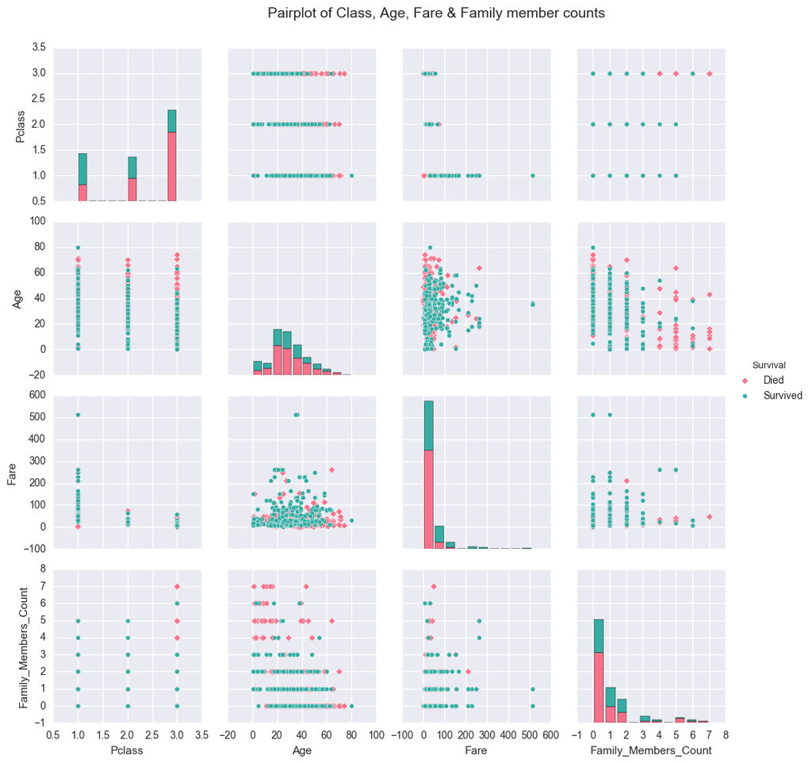

```python
g = sns.pairplot(data=titanic_df.query('Age > 0')[['Survival', 'Pclass', 'Age', 'Fare', 'Family_Members_Count']],
             hue='Survival', markers = ['D', 'o'], palette = 'husl'
            )
#g.fig.suptitle('Pairplot of Class, Age, Fare & Family member counts', verticalalignment='top')
g.fig.text(0.33, 1.02,'Pairplot of Class, Age, Fare & Family member counts', fontsize=14)
show(g)
```

#### General Observations from the pairplot

1. Survivals rates decreased from class 1 to 3.
2. Age is well distributed across classes. Each class has passengers from all the Age groups.
3. Class 1 has highest of the fares and class 2 & 3 both are having very low fares as compared to class 1.
4. Looks like distribution of ages nearly follow the normal distribution. Even the survivals across ages & deaths across ages follow the same.
5. There is not much relationship of fare with respect to Ages.
6. Almost 90% of people paid lesser than 100 pounds as fare. The first bar of the chart (Fare x Fare) probably represetnt the people from class 3.
7. There is a lot of people travelling alone. There are also a good number of people travelling with family. Mostly people are travelling with 1-3 family members.

### Create a function for Hytothesis testing -- Chi test

```python
# Chi Square Testing
def chi_square_test(data):
    chi2, p_value, dof, expected = chi2_contingency(data)
    print "Chi-Squared Score = " + str(chi2)
    print "Pvalue            = " + str(p_value)
    print "\n"
```

### Split the name & Extract the Salutations

```python
#### Function to split name into Salutation, First Name, Middle Name, Last Name
def split_name(name):
    last_name, fm_name = tuple(name.split('(')[0].split(','))
    fm_name = fm_name.split()
    salutation, first_name, middle_name = '', '', ''
    try:
        salutation = fm_name[0]
        first_name = fm_name[1]
        middle_name = fm_name[2]
    except IndexError:
        pass
    return salutation.strip(), first_name.strip(), middle_name.strip(), last_name.strip()
```

```python
titanic_df['Salutation'], titanic_df['First_Name'], titanic_df['Middle_Name'], titanic_df['Last_Name'] = titanic_df['Name'].apply(split_name).str
titanic_df=titanic_df.drop('Name', axis=1)
titanic_df.head(2)
```

|  | PassengerId | Survived | Pclass | Sex | Age | SibSp | Parch | Ticket | Fare | Cabin | Embarked | Survival | Class | Family_Members_Count | Salutation | First_Name | Middle_Name | Last_Name |
| --- | --- | --- | --- | --- | --- | --- | --- | --- | --- | --- | --- | --- | --- | --- | --- | --- | --- | --- |
| 0 | 1 | 0 | 3 | M | 22.0 | 1 | 0 | A/5 21171 | 7.2500 | NaN | Southampton | Died | Third Class | 1 | Mr. | Owen | Harris | Braund |
| 1 | 2 | 1 | 1 | F | 38.0 | 1 | 0 | PC 17599 | 71.2833 | C85 | Cherbourg | Survived | First Class | 1 | Mrs. | John | Bradley | Cumings |

## Survival Rates

```python
### Survival rates
survival_rates = (titanic_df['Survival'].value_counts() / num_rows * 100).round(2)
survival_rates
```

```
Died        61.62
Survived    38.38
Name: Survival, dtype: float64
```

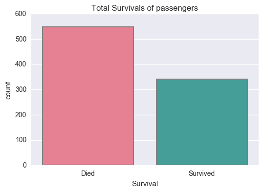

```python
g = sns.countplot(data=titanic_df, x="Survival",
              palette='husl', edgecolor='grey', linewidth=1.5)
sns.plt.title("Total Survivals of passengers")
show(g)
```

## Survival Rates by Sex

```python
# Sex to Survivability
pivot = pd.pivot_table(data = titanic_df[['Survival', 'Sex']], index = 'Survival', columns = ['Sex'], aggfunc = len)
pivot
```

| Sex Survival | F | M |
| --- | --- | --- |
| Died | 81 | 468 |
| Survived | 233 | 109 |

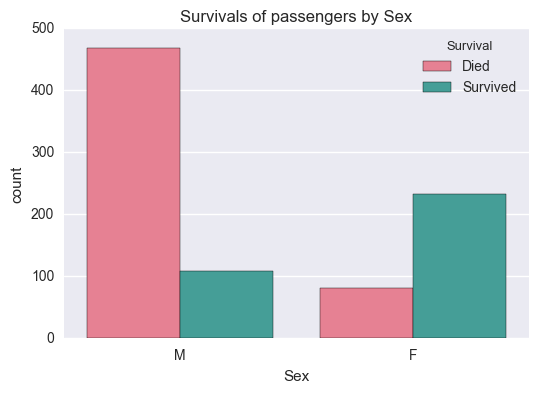

```python
g = sns.countplot(data=titanic_df, x="Sex", hue="Survival", palette="husl")
sns.plt.title("Survivals of passengers by Sex")
show(g)
```

### - Looking at the above chart it's obvious that Females has a better chance of Survivals as compared to males. To confirm this we will do a hypothesis testing on this.

### Hypothesis Testing

H0 : There is no significant impact on survivals of sex, i.e., survivals are independent of sex.

H1 : There is significant impact on survivals of sex, i.e., survivals are not independent of sex.

```python
# Chi Square Testing
print "------ Results of Chi-Squared test on Sex to Survival. ------\n"
print "Does Sex have a significant effect on Survival?"

chi_square_test(pivot)
```

```
------ Results of Chi-Squared test on Sex to Survival. ------

Does Sex have a significant effect on Survival?
Chi-Squared Score = 260.717020167
Pvalue            = 1.19735706278e-58
```

### The Chi-square score is very high and p-value is very less showing there is a very strong relationship between Sex and survivals, hence we will reject the null.

## Survival Rates by Class

```python
# Class to Survivability
pivot = pd.pivot_table(data = titanic_df[['Survival', 'Class']], index = 'Survival', columns = ['Class'], aggfunc = len)
pivot
```

| Class Survival | First Class | Second Class | Third Class |
| --- | --- | --- | --- |
| Died | 80 | 97 | 372 |
| Survived | 136 | 87 | 119 |

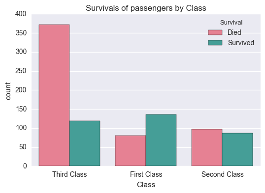

```python
g=sns.countplot ( x = 'Class',
                  hue = 'Survival',
                  data = titanic_df,
                  palette = 'husl'
                )
sns.plt.title("Survivals of passengers by Class")
show(g)
```

### Survival rates are much better for class 1 & 2 passengers as compared to class 3. The survival ratio for class 3 is significantly lower.

### Hypothesis Testing

H0 : There is no significant impact on survivals of class, i.e., survivals are independent of class.

H1 : There is significant impact on survivals of class, i.e., survivals are not independent of class.

```python
# Chi Square Testing
print "------ Results of Chi-Squared test on Class to Survival. ------\n"
print "Does Class have a significant effect on Survival?"

chi_square_test(pivot)
```

```
------ Results of Chi-Squared test on Class to Survival. ------

Does Class have a significant effect on Survival?
Chi-Squared Score = 102.888988757
Pvalue            = 4.5492517113e-23
```

### The Chi-square score is very high and p-value is very less showing there is a very strong relationship between Class and survivals, hence we will reject the null.

## Survival Rates by Embarkment

```python
# Embarkment to Survivability
pivot = pd.pivot_table(data = titanic_df[['Survival', 'Embarked']], index = 'Survival', columns = ['Embarked'], aggfunc = len)
pivot
```

| Embarked Survival | Cherbourg | Queenstown | Southampton |
| --- | --- | --- | --- |
| Died | 75 | 47 | 427 |
| Survived | 93 | 30 | 217 |

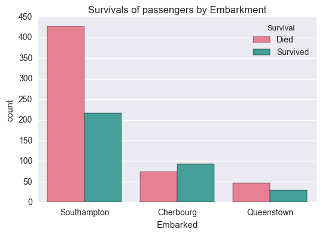

```python
sns.countplot  (x = 'Embarked',
                hue = 'Survival',
                data = titanic_df,
                palette = 'husl'
               )
sns.plt.title("Survivals of passengers by Embarkment")
plt.show()
```

### Survival ratio for people who embarked from Southampton is significantly lower. This maybe the from Southampton more Males boarded or a lot class 3 people boarded, or both.

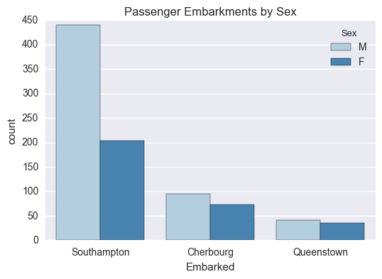

```python
sns.countplot  (x = 'Embarked',
                hue = 'Sex',
                data = titanic_df,
                palette = 'Blues'
               )
sns.plt.title("Passenger Embarkments by Sex")
plt.show()
```

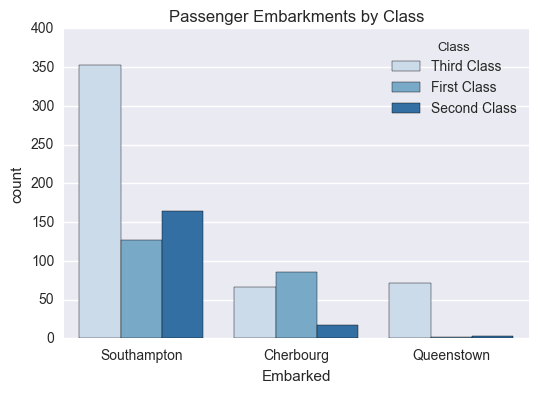

```python
sns.countplot  (x = 'Embarked',
                hue = 'Class',
                data = titanic_df,
                palette = 'Blues'
               )
sns.plt.title("Passenger Embarkments by Class")
plt.show()
```

### We can clearly see that significantly much class 3 people & males embarked from Southampton. This probably caused less survivals for Southampton.

### Embarkment does not have much influence on the survivals.

## Analyse the Titles

Check if the people with special socio-economic status has better chance of surviving.

```python
titanic_df.groupby(by='Salutation')['PassengerId'].count()
### Lots of Salutations, Remove salutaions like Don, Capt, the
```

```
Salutation
Capt.          1
Col.           2
Don.           1
Dr.            7
Jonkheer.      1
Lady.          1
Major.         2
Master.       40
Miss.        182
Mlle.          2
Mme.           1
Mr.          517
Mrs.         125
Ms.            1
Rev.           6
Sir.           1
the            1
Name: PassengerId, dtype: int64
```

```python
titanic_df[titanic_df['Salutation'] == 'Sir.']
```

|  | PassengerId | Survived | Pclass | Sex | Age | SibSp | Parch | Ticket | Fare | Cabin | Embarked | Survival | Class | Family_Members_Count | Salutation | First_Name | Middle_Name | Last_Name |
| --- | --- | --- | --- | --- | --- | --- | --- | --- | --- | --- | --- | --- | --- | --- | --- | --- | --- | --- |
| 599 | 600 | 1 | 1 | M | 49.0 | 1 | 0 | PC 17485 | 56.9292 | A20 | Cherbourg | Survived | First Class | 1 | Sir. | Cosmo | Edmund | Duff Gordon |

```python
### There are special salutaions and can consider them with much social importance as compared to normal people
### Anybody who is having a title of Capt., col., Don., Dr., Major., Sir., the can be
### considered as persons with higher social importance

### Check how many of these people survived
special_title_people = titanic_df[titanic_df['Salutation'].isin(values=['Capt.', 'Col.', 'Don.', 'Dr.', 'Major.', 'Sir.', 'the'])]
special_title_group = special_title_people.groupby(['Survival', 'Salutation'])['Salutation'].count()
special_title_group
### Does not make much sense,, the salutation/ social importance did not mean much while getting life saved
```

```
Survival  Salutation
Died      Capt.         1
          Col.          1
          Don.          1
          Dr.           4
          Major.        1
Survived  Col.          1
          Dr.           3
          Major.        1
          Sir.          1
          the           1
Name: Salutation, dtype: int64
```

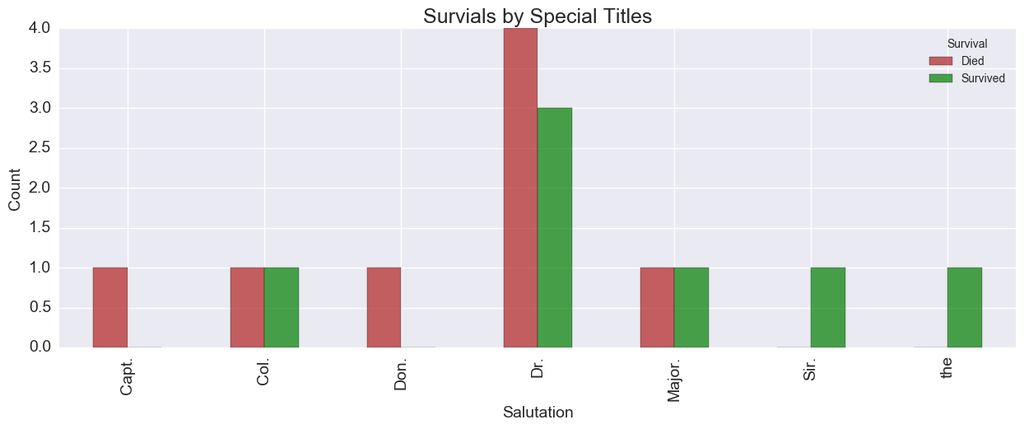

```python
figsize(15, 5)
special_title_group.unstack(level=0, fill_value=0).plot(kind='bar',
                                                        color = ['firebrick', 'green'],
                                                        alpha = 0.7,
                                                        fontsize = 14
                                                       )
plt.title('Survials by Special Titles', fontsize=18)
plt.xlabel("Salutation", fontsize=14)
plt.ylabel("Count", fontsize=14)
plt.show()
```

### The above bar plot shows that special titles or special social statuses do not have much importance on survivals.

```python
### Replace the special Salutation with Simple ones
titanic_df['Salutation'] = titanic_df['Salutation'].replace(\
                            to_replace=['Capt.', 'Col.', 'Don.', 'Dr.', 'Jonkheer.', 'Major.', 'Sir.', 'Rev.'], value='Mr.')
titanic_df['Salutation'] = titanic_df['Salutation'].replace(to_replace=['Mlle.', 'Mme.'], value='Miss.')
titanic_df['Salutation'] = titanic_df['Salutation'].replace(to_replace='Lady.', value='Ms.')
titanic_df['Salutation'] = titanic_df['Salutation'].replace(to_replace='the', value='The')
```

```python
### Group by survivals by Salutations
group_by_salutations = titanic_df.groupby(by=['Survival', 'Salutation'])['PassengerId'].count()
group_by_salutations=group_by_salutations.unstack(level=0, fill_value=0)
group_by_salutations
```

| Survival Salutation | Died | Survived |
| --- | --- | --- |
| Master. | 17 | 23 |
| Miss. | 55 | 130 |
| Mr. | 451 | 87 |
| Mrs. | 26 | 99 |
| Ms. | 0 | 2 |
| The | 0 | 1 |

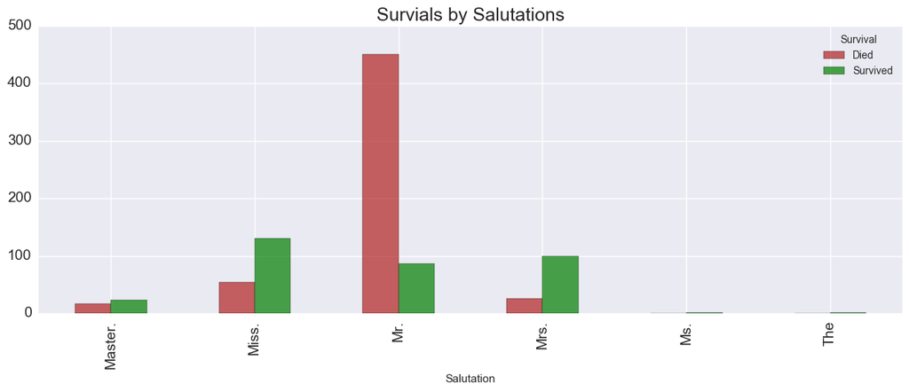

```python
figsize(15, 5)
group_by_salutations.plot(kind='bar', color = ['firebrick', 'green'], alpha = 0.7, fontsize = 14)
plt.title('Survials by Salutations', fontsize=18)
plt.show()
```

### The above bar plot shows that mostly kids and females have a very good percentage of survivals as compared to that of Males. Females have much better chance of survival as compared to children.

```python
a, b = tuple(titanic_df[titanic_df['Salutation'] == 'Master.'].groupby(['Survival']).size())
print 'Kids survival rate -- ' +str(b*100.0/(a+b))
titanic_df[titanic_df['Salutation'] == 'Master.'].groupby(['Class', 'Survival']).size().unstack().fillna(0)
```

```
Kids survival rate -- 57.5
```

| Survival Class | Died | Survived |
| --- | --- | --- |
| First Class | 0.0 | 3.0 |
| Second Class | 0.0 | 9.0 |
| Third Class | 17.0 | 11.0 |

### Interestingly all the kids were saved from class 1 & 2. There were a lot of kids from class 3 drowned.

```python
a, b = tuple(titanic_df[titanic_df['Salutation'].isin(['Miss.', 'Ms.', 'Mrs', 'the'])].groupby(by='Survival').size())
print 'Women survival rate -- ' +str(b*100.0/(a+b))
titanic_df[titanic_df['Salutation'].isin(['Miss.', 'Ms.', 'Mrs', 'the'])].groupby(['Class', 'Survival']).size().unstack().fillna(0)
```

```
Women survival rate -- 70.5882352941
```

| Survival Class | Died | Survived |
| --- | --- | --- |
| First Class | 2 | 48 |
| Second Class | 2 | 33 |
| Third Class | 51 | 51 |

```python
### Survivals of Kids
titanic_df.query('Age <= 15').groupby(by="Survival").size()
```

```
Survival
Died        34
Survived    49
dtype: int64
```

```python
### Survivals of Females
titanic_df.query('Sex <= "F"').groupby(by="Survival").size()
```

```
Survival
Died         81
Survived    233
dtype: int64
```

### This statistics also shows that females have a better chance of surviving as compared to kids.

## Analysis by Sex, Class together

```python
sex_class_group = titanic_df.groupby(by=['Sex', 'Class', 'Survival'])['PassengerId'].count().unstack(level=-1)
sex_class_group
```

| Sex | Survival Class | Died | Survived |
| --- | --- | --- | --- |
| F | First Class | 3 | 91 |
|  | Second Class | 6 | 70 |
|  | Third Class | 72 | 72 |
| M | First Class | 77 | 45 |
|  | Second Class | 91 | 17 |
|  | Third Class | 300 | 47 |

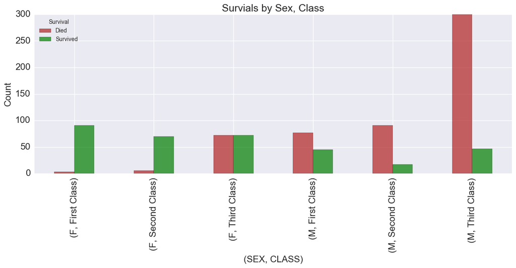

```python
figsize(15, 5)
sex_class_group.plot(kind='bar', color = ['firebrick', 'green'], alpha = 0.7, fontsize=16)
plt.title('Survials by Sex, Class', fontsize=18)
plt.xlabel('(SEX, CLASS)', fontsize = 16)
plt.ylabel('Count', fontsize = 16)
plt.show()
```

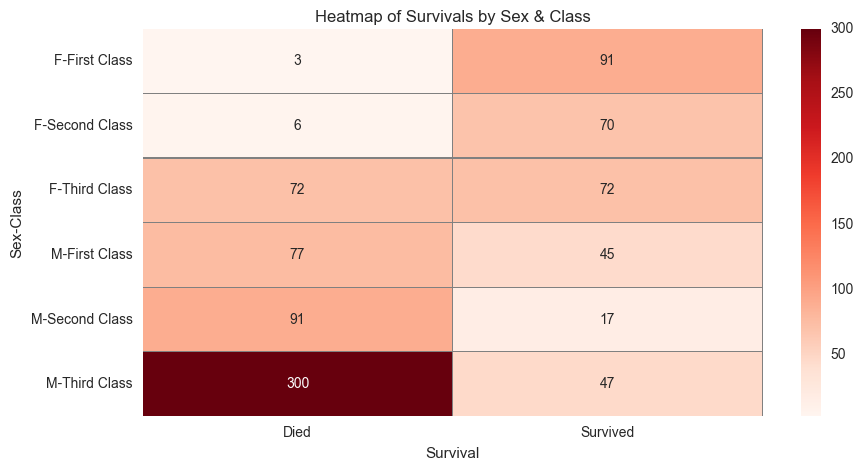

```python
p=figsize(10, 5)
g=sns.heatmap(sex_class_group, annot=True,
              fmt="d", linewidths=0.2,
              linecolor="grey", cmap="Reds"
             )
plt.title("Heatmap of Survivals by Sex & Class")
show(plt)
```

### Both of the charts show that a lot of females survived as compared to males. Also class 3 males have the lowest survival.

### Hypothesis Testing

H0 : There is no significant impact on survivals of sex and class, i.e., survivals are independent of sex and class together.

H1 : There is significant impact on survivals of sex and class, i.e., survivals are not independent of sex and class together.

```python
# Sex, Class to Survivability
pivot = pd.pivot_table(data = titanic_df[['Survival', 'Sex', 'Class']], index = 'Survival', columns = ['Class', 'Sex'],
                       aggfunc = len)
pivot
```

| Class Sex Survival | First Class F | First Class M | Second Class F | Second Class M | Third Class F | Third Class M |
| --- | --- | --- | --- | --- | --- | --- |
| Died | 3 | 77 | 6 | 91 | 72 | 300 |
| Survived | 91 | 45 | 70 | 17 | 72 | 47 |

```python
# Chi Square Testing
print "------ Results of Chi-Squared test on Sex+Class to Survival. ------\n"
print "Does Sex+Class have a significant effect on Survival?"

chi_square_test(pivot)
```

```
------ Results of Chi-Squared test on Sex+Class to Survival. ------

Does Sex+Class have a significant effect on Survival?
Chi-Squared Score = 350.675308396
Pvalue            = 1.25230734736e-73
```

### The Chi-square score is very high and p-value is very less showing there is a very strong dependence of Sex and Class on survivals, hence we will reject the null.

## Analyse the ages

```python
### Mean Age & SD of Ages of the passengers
desc_ages = titanic_df['Age'].describe().round(2)
desc_ages
```

```
count    714.00
mean      29.70
std       14.53
min        0.42
25%         NaN
50%         NaN
75%         NaN
max       80.00
Name: Age, dtype: float64
```

#### Plot distribution of ages ignoring the NAN records

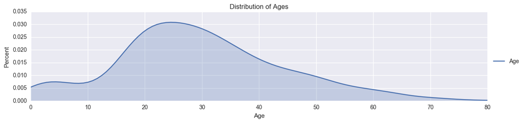

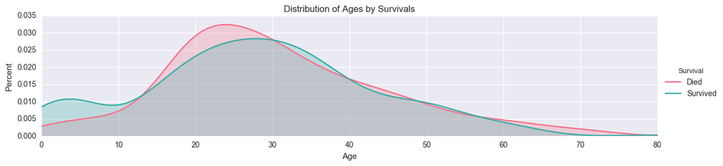

```python
# Distribution plot for survived/not survived passengers by their age
facet = sns.FacetGrid(titanic_df,aspect=4)
facet.map(sns.kdeplot,'Age',shade= True)
facet.set(xlim=(0, titanic_df['Age'].max()))
facet.add_legend()
plt.title("Distribution of Ages")
plt.ylabel("Percent")
show(facet)

facet = sns.FacetGrid(titanic_df,aspect=4, hue='Survival', palette='husl')
facet.map(sns.kdeplot,'Age',shade= True)
facet.set(xlim=(0, titanic_df['Age'].max()))
facet.add_legend()
plt.title("Distribution of Ages by Survivals")
plt.ylabel("Percent")
show(facet)
```

### Ages seems to follow the normal distribution approximately.

#### Distribution of Ages by Sex

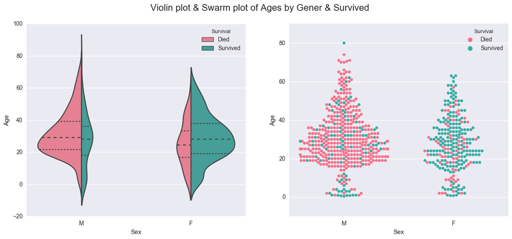

```python
figsize(15, 6)
fig, axs = plt.subplots(ncols=2)
fig.suptitle("Violin plot & Swarm plot of Ages by Gener & Survived", fontsize=16)
sns.violinplot(data = titanic_df,
               x = 'Sex', y='Age',
               hue='Survival',
               split=True,
               palette='husl',
               scale='count',
               inner = 'quartile',
               ax=axs[0]
              )
sns.swarmplot(data=titanic_df,
              x="Sex",
              y="Age",
              hue="Survival",
              palette='husl',
              ax=axs[1]
             )
show()
```

### The above charts shows again that the females survived much more as compared to males. Survials & non-survivals are approximately evenly distribution over the ages. For males the ages are more spread with a lot of males over age 60.

#### Distribution of Ages by Class

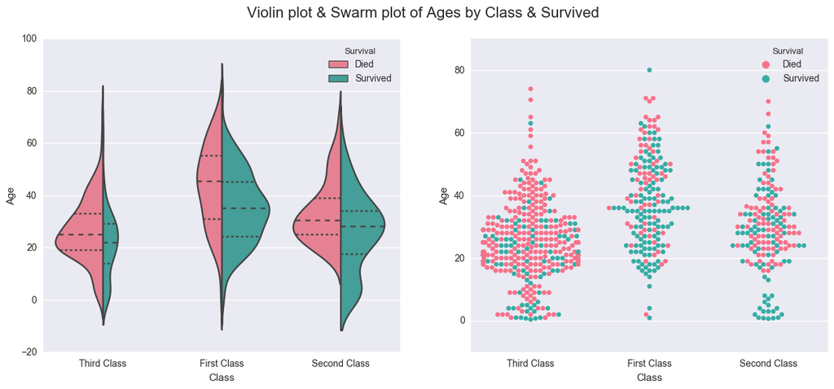

```python
figsize(15, 6)
fig, axs = plt.subplots(ncols=2)
fig.suptitle("Violin plot & Swarm plot of Ages by Class & Survived", fontsize=16)
sns.violinplot(data = titanic_df,
               x = 'Class', y='Age',
               hue='Survival',
               split=True,
               palette='husl',
               scale='count',
               inner = 'quartile',
               ax=axs[0]
              )
sns.swarmplot(data=titanic_df,
              x="Class",
              y="Age",
              hue="Survival",
              palette='husl',
              ax=axs[1]
             )
show()
```

```python
titanic_df[['Class', 'Age']].groupby(by='Class').mean()
```

| Class | Age |
| --- | --- |
| First Class | 38.233441 |
| Second Class | 29.877630 |
| Third Class | 25.140620 |

### Age distribution is almost similar across classes. The surviavls decresed significantly from class 1 to 3. From the plots and mean we can see that the ages centered at around 38 for class 1, 30 for class 2, 25 for class 3. Surprisingly class 1 does not have much kids.

### Replace the NAN ages with the most like ages within the title category

There are a number of records with missing data for Age. We will not replace them as 0 because that will make 177 persons as aged 0 & in histogram 0 will have a high frequency corrupting the distribution of Ages. We will also not ignore these records as doing so will result in losing around one-fifth of the records.

```python
### Find NAN data for Age
age_NANs = titanic_df[titanic_df['Age'].isnull()].head(5)
age_NANs_index = age_NANs.index.values.tolist()

### Replace Age NANs by the Salutation average age
avg_age_by_salutation = titanic_df.groupby(by = 'Salutation').mean()['Age']
avg_age_by_salutation
```

```
Salutation
Master.     4.574167
Miss.      21.818792
Mr.        33.022727
Mrs.       35.898148
Ms.        38.000000
The        33.000000
Name: Age, dtype: float64
```

```python
sd_age_by_salutation = titanic_df.groupby(by = 'Salutation').std()['Age']
sd_age_by_salutation = sd_age_by_salutation.fillna(value=0)
sd_age_by_salutation
```

```
Salutation
Master.     3.619872
Miss.      12.861787
Mr.        12.996267
Mrs.       11.433628
Ms.        14.142136
The         0.000000
Name: Age, dtype: float64
```

```python
def replace_missing_ages(title):
    return np.random.randint(low = max(0, avg_age_by_salutation[title] - np.random.random() * sd_age_by_salutation[title]), \
                  high = avg_age_by_salutation[title] + np.random.random() * sd_age_by_salutation[title])
```

```python
## Replace NAN age
titanic_df['Age'] = titanic_df['Age'].add(titanic_df[titanic_df['Age'].isnull()]['Salutation'].apply(replace_missing_ages), fill_value=0)
titanic_df.head()
```

|  | PassengerId | Survived | Pclass | Sex | Age | SibSp | Parch | Ticket | Fare | Cabin | Embarked | Survival | Class | Family_Members_Count | Salutation | First_Name | Middle_Name | Last_Name |
| --- | --- | --- | --- | --- | --- | --- | --- | --- | --- | --- | --- | --- | --- | --- | --- | --- | --- | --- |
| 0 | 1 | 0 | 3 | M | 22.0 | 1 | 0 | A/5 21171 | 7.2500 | NaN | Southampton | Died | Third Class | 1 | Mr. | Owen | Harris | Braund |
| 1 | 2 | 1 | 1 | F | 38.0 | 1 | 0 | PC 17599 | 71.2833 | C85 | Cherbourg | Survived | First Class | 1 | Mrs. | John | Bradley | Cumings |
| 2 | 3 | 1 | 3 | F | 26.0 | 0 | 0 | STON/O2. 3101282 | 7.9250 | NaN | Southampton | Survived | Third Class | 0 | Miss. | Laina |  | Heikkinen |
| 3 | 4 | 1 | 1 | F | 35.0 | 1 | 0 | 113803 | 53.1000 | C123 | Southampton | Survived | First Class | 1 | Mrs. | Jacques | Heath | Futrelle |
| 4 | 5 | 0 | 3 | M | 35.0 | 0 | 0 | 373450 | 8.0500 | NaN | Southampton | Died | Third Class | 0 | Mr. | William | Henry | Allen |

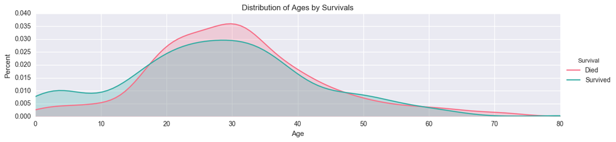

```python
# Plot distribution of Ages after correction
facet = sns.FacetGrid(titanic_df,aspect=4, hue='Survival', palette='husl')
facet.map(sns.kdeplot,'Age',shade= True)
facet.set(xlim=(0, titanic_df['Age'].max()))
facet.add_legend()
plt.title("Distribution of Ages by Survivals")
plt.ylabel("Percent")
show(facet)
```

### Looks like the distribution hump/mode shifted a bit towards right. This is due to the NAN ages are replaced with probable values from particular age intervals.

### And the height also now increased slightly by 5%. We can see it's still following the normal distribution approximately.

#### Create age groups & assign age groups to passengers

Age Groups --> Child(0 - 15), Youth(15 - 25), Adult(25-40), Mid-Age(40-55), Old(55-70), and Very Old(> 70)

```python
titanic_df['Age_Group'] = pd.cut(titanic_df['Age'],
       bins=[0, 15, 25, 40, 55, 70, 90],
       labels=['Child', 'Youth', 'Adult', 'Mid-Age', 'Old', 'Very Old']
      )
titanic_df.head(3)
```

|  | PassengerId | Survived | Pclass | Sex | Age | SibSp | Parch | Ticket | Fare | Cabin | Embarked | Survival | Class | Family_Members_Count | Salutation | First_Name | Middle_Name | Last_Name | Age_Group |
| --- | --- | --- | --- | --- | --- | --- | --- | --- | --- | --- | --- | --- | --- | --- | --- | --- | --- | --- | --- |
| 0 | 1 | 0 | 3 | M | 22.0 | 1 | 0 | A/5 21171 | 7.2500 | NaN | Southampton | Died | Third Class | 1 | Mr. | Owen | Harris | Braund | Youth |
| 1 | 2 | 1 | 1 | F | 38.0 | 1 | 0 | PC 17599 | 71.2833 | C85 | Cherbourg | Survived | First Class | 1 | Mrs. | John | Bradley | Cumings | Adult |
| 2 | 3 | 1 | 3 | F | 26.0 | 0 | 0 | STON/O2. 3101282 | 7.9250 | NaN | Southampton | Survived | Third Class | 0 | Miss. | Laina |  | Heikkinen | Adult |

```python
# Age groups to Survivability
pivot = pd.pivot_table(data = titanic_df[['Survival', 'Age_Group']],
                       index = 'Survival', columns = ['Age_Group'], aggfunc = len)
pivot
```

| Age_Group Survival | Adult | Child | Mid-Age | Old | Very Old | Youth |
| --- | --- | --- | --- | --- | --- | --- |
| Died | 250 | 38 | 72 | 24 | 4 | 161 |
| Survived | 139 | 58 | 43 | 11 | 1 | 90 |

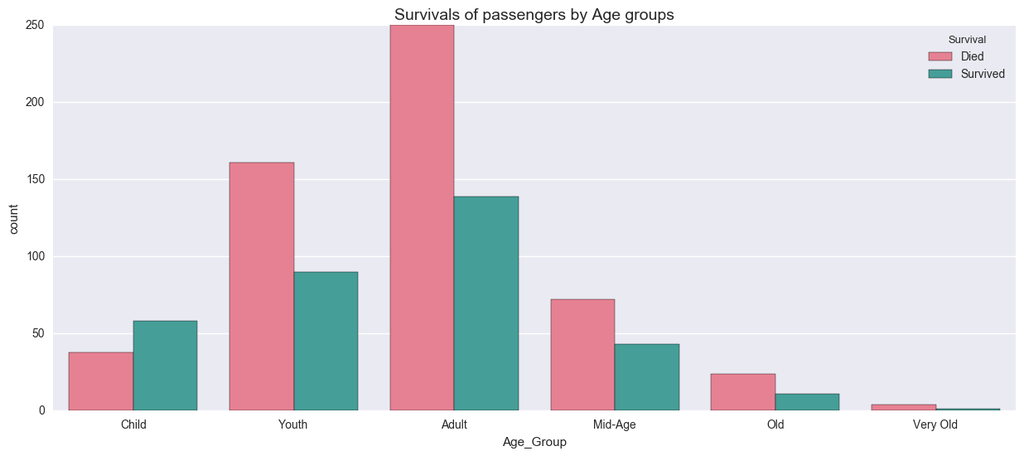

```python
# Plot distribution of Age Group Survivals
g=sns.countplot(x = 'Age_Group',
              hue = 'Survival',
              data = titanic_df,
              palette = 'husl'
             )
sns.plt.title("Survivals of passengers by Age groups", fontsize=14)
show(g)
```

### In general children have much better survival ratios. This chart is also following a normal distribution approximately. Other age groups do not help much on the survival.

### Hypothesis Testing -- Age groups does not have much effect on survivals

H0 : There is no significant impact on survivals of age groups, i.e., survivals are independent of age groups.

H1 : There is significant impact on survivals of age groups, i.e., survivals are not independent of age groups.

```python
# Chi Square Testing
print "------ Results of Chi-Squared test on Sex to Survival. ------\n"
print "Does Sex have a significant effect on Survival?"

chi_square_test(pivot)
```

```
------ Results of Chi-Squared test on Sex to Survival. ------

Does Sex have a significant effect on Survival?
Chi-Squared Score = 23.0168743903
Pvalue            = 0.000335067842187
```

### The Chi-square score is somewhat high and p-value is less showing there is a somewhat good relationship between Age Groups and survivals, hence we can reject the null for most of the p-values.

### Hypothesis Testing -- Children have a better survival chances compared to other Age groups

H0 : There is no significant impact on survivals of age groups other than children, i.e., survivals are independent of age groups other than children.

H1 : There is significant impact on survivals of age groups other than children, i.e., survivals are not independent of age groups other than children.

```python
# Age groups to Survivability
pivot = pd.pivot_table(data = titanic_df.query('Age_Group != "Child"')[['Survival', 'Age_Group']],
                       index = 'Survival', columns = ['Age_Group'], aggfunc = len)
pivot
```

| Age_Group Survival | Adult | Mid-Age | Old | Very Old | Youth |
| --- | --- | --- | --- | --- | --- |
| Died | 250 | 72 | 24 | 4 | 161 |
| Survived | 139 | 43 | 11 | 1 | 90 |

```python
# Chi Square Testing
print "------ Results of Chi-Squared test on Sex to Survival. ------\n"
print "Does Sex have a significant effect on Survival?"

chi_square_test(pivot)
```

```
------ Results of Chi-Squared test on Sex to Survival. ------

Does Sex have a significant effect on Survival?
Chi-Squared Score = 0.960782494561
Pvalue            = 0.915683188542
```

### The Chi-square score is less and p-value is bigger showing there is a not much good relationship between Age Groups(without Children) and survivals, hence we can accept the null.

### Based on the above results we can tell that age groups other than children have a similar survival chances across all the groups. Children have a much better chances as without children the p-value is much bigger and including children the p-value is very less.

```python
survived_by_age_grp = titanic_df[titanic_df['Survived'] == 1].groupby(by = 'Age_Group').count()['Survived']
```

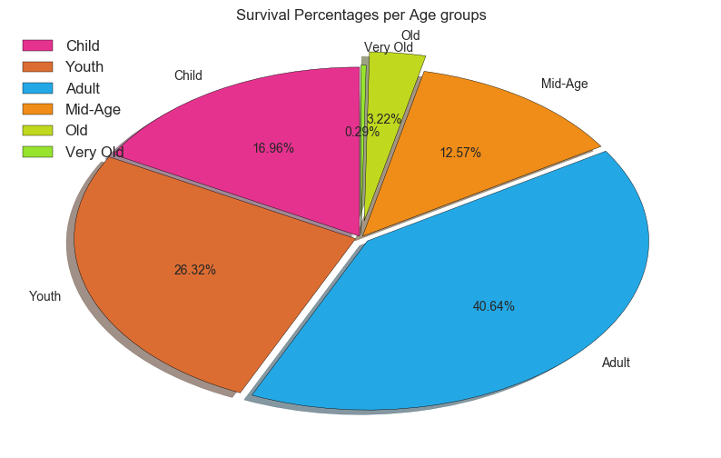

```python
figsize(10, 6)
explode = (0.01, 0.02, 0.03, 0.01, 0.1, 0.02)
colors = ['#E6328F', '#DC6D32', '#24A8E5', '#EF8D18', '#C0D91F', '#97E32E']
survived_by_age_grp.plot(kind='pie', explode = explode, colors = colors,
                         autopct='%1.2f%%', shadow=True, startangle=90)
plt.legend(survived_by_age_grp.index, loc=2, fontsize=12)
plt.title('Survival Percentages per Age groups', fontsize=12)
plt.ylabel('')
plt.show()
```

### Fares across Age groups & Class

```python
### MEAN fare across Age groups
fare_by_age_grp = titanic_df.groupby(by = ['Class', 'Age_Group']).mean()['Fare'].unstack().fillna(0).round(2)
fare_by_age_grp
```

| Age_Group Class | Child | Youth | Adult | Mid-Age | Old | Very Old |
| --- | --- | --- | --- | --- | --- | --- |
| First Class | 135.31 | 106.77 | 83.64 | 70.75 | 67.47 | 38.05 |
| Second Class | 27.53 | 23.97 | 17.87 | 19.73 | 15.26 | 0.00 |
| Third Class | 22.49 | 11.25 | 13.14 | 12.26 | 7.78 | 7.76 |

### Surprisingly mean fares have a negative trends across age groups. Children paid the most and Old people paid the less.

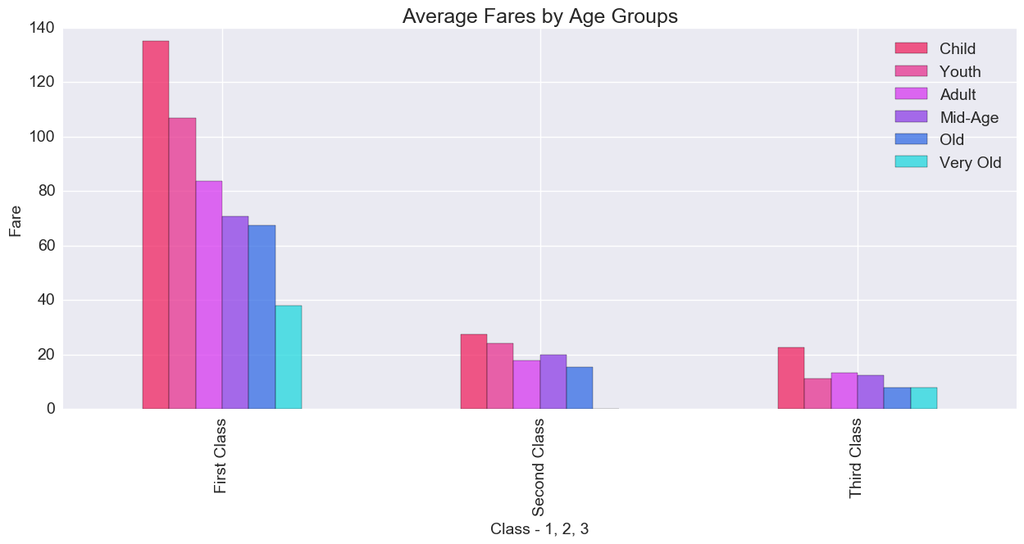

```python
figsize(15, 6)
fare_by_age_grp.plot(kind='bar',
                     alpha=0.75,
                     color=['#F02361', '#E6328F', '#D738F0', '#8D3EE6', '#336CE5', '#20D8DE'],
                     fontsize=14
                    )
plt.title('Average Fares by Age Groups', fontsize = 18)
plt.xlabel('Class - 1, 2, 3', fontsize=14)
plt.ylabel('Fare', fontsize=14)
plt.legend(fontsize=14)
plt.show()
```

### Check if fare has any impact on the Survival chances

```python
#### Does Fare has any impact on survivals -- No null values in Fare
titanic_df['Fare'].describe().round(2)
```

```
count    891.00
mean      32.20
std       49.69
min        0.00
25%        7.91
50%       14.45
75%       31.00
max      512.33
Name: Fare, dtype: float64
```

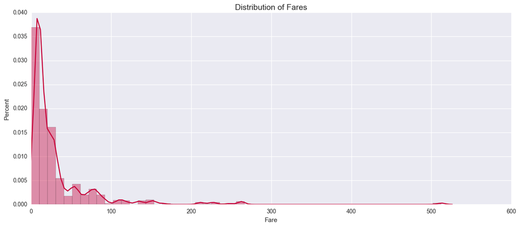

```python
# Plot distribution of Fares
g=sns.distplot(titanic_df["Fare"], color='#C70039')
sns.plt.title("Distribution of Fares", fontsize=14)
g.set_xlim(left=0)
plt.ylabel("Percent")
plt.show()
```

### Looks like most of the fares are within 30 pounds.

##### While analysing found some records with ZERO fares & No Ticket numer

```python
### We can see some fares as ZERO -- are they travelling free?
titanic_df.query('Fare == 0').head()
```

|  | PassengerId | Survived | Pclass | Sex | Age | SibSp | Parch | Ticket | Fare | Cabin | Embarked | Survival | Class | Family_Members_Count | Salutation | First_Name | Middle_Name | Last_Name | Age_Group |
| --- | --- | --- | --- | --- | --- | --- | --- | --- | --- | --- | --- | --- | --- | --- | --- | --- | --- | --- | --- |
| 179 | 180 | 0 | 3 | M | 36.0 | 0 | 0 | LINE | 0.0 | NaN | Southampton | Died | Third Class | 0 | Mr. | Lionel |  | Leonard | Adult |
| 263 | 264 | 0 | 1 | M | 40.0 | 0 | 0 | 112059 | 0.0 | B94 | Southampton | Died | First Class | 0 | Mr. | William |  | Harrison | Adult |
| 271 | 272 | 1 | 3 | M | 25.0 | 0 | 0 | LINE | 0.0 | NaN | Southampton | Survived | Third Class | 0 | Mr. | William | Henry | Tornquist | Youth |
| 277 | 278 | 0 | 2 | M | 29.0 | 0 | 0 | 239853 | 0.0 | NaN | Southampton | Died | Second Class | 0 | Mr. | Francis | "Frank" | Parkes | Adult |
| 302 | 303 | 0 | 3 | M | 19.0 | 0 | 0 | LINE | 0.0 | NaN | Southampton | Died | Third Class | 0 | Mr. | William | Cahoone | Johnson | Youth |

```python
### There are people with ticket numbers but few records are ticket number as line
titanic_df.query('Fare == 0 and Ticket == "LINE"')
```

|  | PassengerId | Survived | Pclass | Sex | Age | SibSp | Parch | Ticket | Fare | Cabin | Embarked | Survival | Class | Family_Members_Count | Salutation | First_Name | Middle_Name | Last_Name | Age_Group |
| --- | --- | --- | --- | --- | --- | --- | --- | --- | --- | --- | --- | --- | --- | --- | --- | --- | --- | --- | --- |
| 179 | 180 | 0 | 3 | M | 36.0 | 0 | 0 | LINE | 0.0 | NaN | Southampton | Died | Third Class | 0 | Mr. | Lionel |  | Leonard | Adult |
| 271 | 272 | 1 | 3 | M | 25.0 | 0 | 0 | LINE | 0.0 | NaN | Southampton | Survived | Third Class | 0 | Mr. | William | Henry | Tornquist | Youth |
| 302 | 303 | 0 | 3 | M | 19.0 | 0 | 0 | LINE | 0.0 | NaN | Southampton | Died | Third Class | 0 | Mr. | William | Cahoone | Johnson | Youth |
| 597 | 598 | 0 | 3 | M | 49.0 | 0 | 0 | LINE | 0.0 | NaN | Southampton | Died | Third Class | 0 | Mr. | Alfred |  | Johnson | Mid-Age |

### I can see there are 4 records with fare as ZERO and ticket number as LINE -- Does it mean that these people are crew???

#### After some reseach i got the following

I got some information from http://www.lva.virginia.gov/exhibits/titanic/crew.htm for 3 persons from the above list. I see they were crew members from another ship/vessel but did not work as crews in Titanic.

Below extracted data for them. From the description we can understand why the Fare was ZERO & the ticket number was LINE.

Name Home City Rating Saved Lifeboat Body Disposition

Johnson, A. . Not Titanic crew, American Line man traveling as passenger . . .

Johnson, W. . Not Titanic crew, American Line man traveling as passenger . . .

Leonard, L. . Not Titanic crew, American Line man traveling as passenger . . .

I was searching for the remaining person "Mr. William Henry Tornquist" and find details on him in the titanic encyclopaedia website. https://www.encyclopedia-titanica.org/titanic-survivor/william-henry-tornquist.html

The below details was provided for him & other 3 persons.

He had made a visit to relatives in Stockholm and was returning to New York. His last job had been as mate on the American Line vessel New York, the ship that almost collided with Titanic as she left Southampton. He travelled as a third class passenger (ticket number 370160) together with fellow American Line employees: William Cahoone Johnson Jr., Alfred Johnson, Lionel Leonard, Alfred Carver and Thomas Storey

Even in wikipedia I find the persons are in the 3rd class passengers list. So I think they were crew members by profession but were passengers in Titanic.

### Plot a boxplot of Fares by class

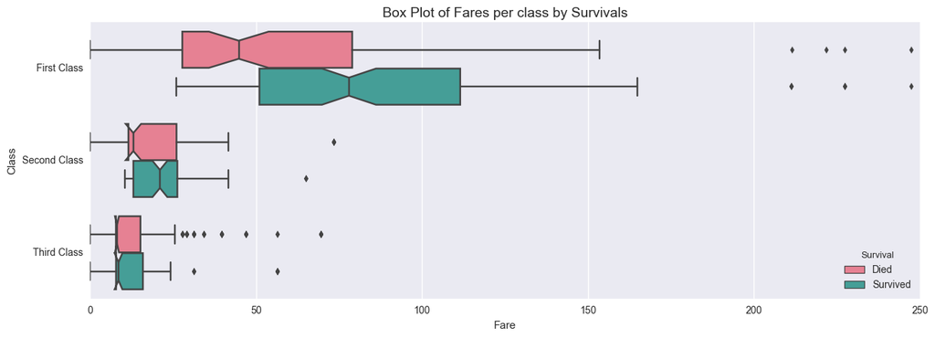

```python
figsize(15, 5)
g = sns.boxplot(y="Class", x="Fare", hue="Survival", data=titanic_df, order=['First Class', 'Second Class', 'Third Class'],
                palette="husl", notch=True, orient='h')
g.set_xlim(left=0, right=250)
sns.plt.title("Box Plot of Fares per class by Survivals", fontsize=14)
show(g)
```

#### There are a number of outliers for class 1, remove them

```python
### Cut off the outliers
## Get Max threshold & cut off values more than the threshold
mean, std = tuple(titanic_df['Fare'].describe()[["mean", "std"]])
fare_threshold_value = mean + (1.96 * std)
fare_threshold_value
```

```
129.60332801904917
```

```python
### Cut off outlier fares
print 'Fare stats with outliers'
print '-' * 40
print titanic_df['Fare'].describe().round(2)

print 'Fare stats without outliers'
print '-' * 40
fares_wo_outliers = titanic_df.query('Fare <= @fare_threshold_value')
fares_wo_outliers['Fare'].describe().round(2)
```

```
Fare stats with outliers
----------------------------------------
count    891.00
mean      32.20
std       49.69
min        0.00
25%        7.91
50%       14.45
75%       31.00
max      512.33
Name: Fare, dtype: float64
Fare stats without outliers
----------------------------------------
```

```
count    853.00
mean      24.00
std       23.84
min        0.00
25%        7.90
50%       13.00
75%       28.50
max      120.00
Name: Fare, dtype: float64
```

### Compare Fare distribution with & without outliers

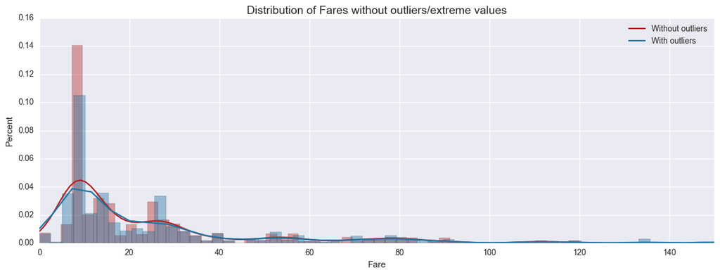

```python
# Distribution plot for survived/not survived passengers by their age
figsize(15, 5)
g=sns.distplot(fares_wo_outliers['Fare'], bins=50,
               kde_kws={"color":"firebrick", "label":"Without outliers"},
               hist_kws={"color":"firebrick"}
              )
sns.distplot(titanic_df['Fare'], bins=200,
             kde_kws={"label":"With outliers", "color":"#1E76A5"},
             hist_kws={"color":"#1E76A5"}
            )
g.set_xlim(left=0, right=150)
plt.ylabel("Percent")
sns.plt.title("Distribution of Fares without outliers/extreme values", fontsize=14)
show(g)
```

### Display boxplot without outliers

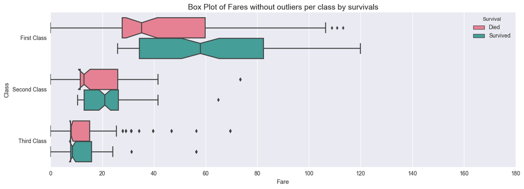

```python
## Box Plot by class
figsize(15, 5)
g = sns.boxplot(y="Class", x="Fare", hue="Survival", data=fares_wo_outliers,
                order=['First Class', 'Second Class', 'Third Class'],
                palette="husl", notch=True, orient='h')
g.set_xlim(left=0, right=180)
sns.plt.title("Box Plot of Fares without outliers per class by survivals", fontsize=14)
show(g)
```

### Boxplots showing the comparison among the classes. Survivals does not much depend on the fares within a class.

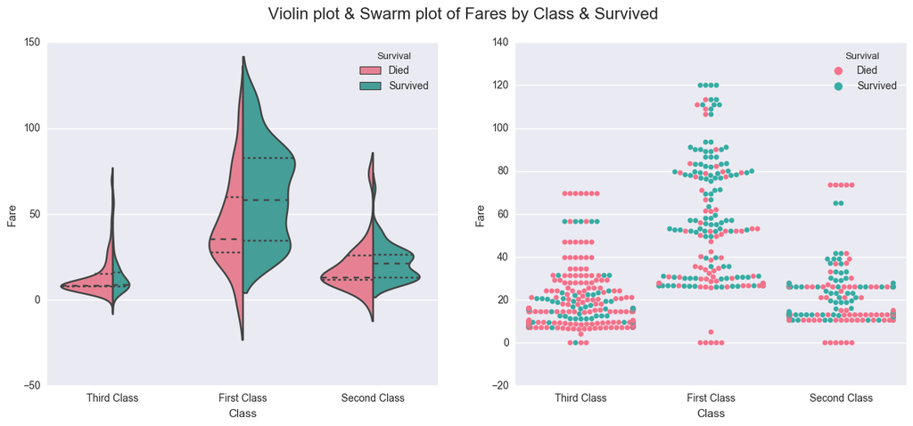

```python
figsize(15, 6)
fig, axs = plt.subplots(ncols=2)
sns.violinplot(data = fares_wo_outliers, x = 'Class', y='Fare',
               hue='Survival', split=True, palette='husl',
               scale='count', inner = 'quartile', ax=axs[0]
              )
sns.swarmplot(data=fares_wo_outliers,
              x="Class",
              y="Fare",
              hue="Survival",
              palette='husl',
              ax=axs[1]
             )
fig.suptitle("Violin plot & Swarm plot of Fares by Class & Survived", fontsize=16)
show()
```

### In general it does not look like the fares have much influence on survival other than class 1. Class 1 has higher fares and much higher survivals.

### Class 2 & 3 have almost same fares but survival rate is very low in class 3.

## Create Fare groups & analyse per fare groups

```python
### Fares with Survivals -- Create Fare Groups
def create_fare_group(fare):
    if fare > fare_threshold_value:
        return "Outliers"
    else:
        fare_group = int(fare) / 10
        return "{} to {}".format(str(fare_group * 10 ), str((fare_group+1) * 10 ))
```

```python
titanic_df['Fare_Group'] = titanic_df['Fare'].apply(create_fare_group)
titanic_df.head(3)
```

|  | PassengerId | Survived | Pclass | Sex | Age | SibSp | Parch | Ticket | Fare | Cabin | Embarked | Survival | Class | Family_Members_Count | Salutation | First_Name | Middle_Name | Last_Name | Age_Group | Fare_Group |
| --- | --- | --- | --- | --- | --- | --- | --- | --- | --- | --- | --- | --- | --- | --- | --- | --- | --- | --- | --- | --- |
| 0 | 1 | 0 | 3 | M | 22.0 | 1 | 0 | A/5 21171 | 7.2500 | NaN | Southampton | Died | Third Class | 1 | Mr. | Owen | Harris | Braund | Youth | 0 to 10 |
| 1 | 2 | 1 | 1 | F | 38.0 | 1 | 0 | PC 17599 | 71.2833 | C85 | Cherbourg | Survived | First Class | 1 | Mrs. | John | Bradley | Cumings | Adult | 70 to 80 |
| 2 | 3 | 1 | 3 | F | 26.0 | 0 | 0 | STON/O2. 3101282 | 7.9250 | NaN | Southampton | Survived | Third Class | 0 | Miss. | Laina |  | Heikkinen | Adult | 0 to 10 |

```python
# Survivals per fare group
total_people_by_fare_grp = titanic_df.groupby(by = 'Fare_Group').size()
survivals_by_fare_grp = titanic_df[titanic_df['Survived'] == 1].groupby(by = 'Fare_Group').count()['Survived']

temp_index = total_people_by_fare_grp.index.to_series()[:-1].apply(lambda string : int(string.split()[0])).sort_values()
temp_index = temp_index.append(pd.Series(['Outliers'], index=['Outliers']))
total_people_by_fare_grp.index = temp_index.index

temp_index = survivals_by_fare_grp.index.to_series()[:-1].apply(lambda string : int(string.split()[0])).sort_values()
temp_index = temp_index.append(pd.Series(['Outliers'], index=['Outliers']))
survivals_by_fare_grp.index = temp_index.index


print "People by fare Group"
print "-" * 40
print total_people_by_fare_grp

print "\nSurvived by fare Group"
print "-" * 40
print survivals_by_fare_grp

#total_people_by_fare_grp = total_people_by_fare_grp / num_rows
#survivals_by_fare_grp = survivals_by_fare_grp / num_rows
```

```
People by fare Group
----------------------------------------
Fare_Group
0 to 10       336
10 to 20      179
20 to 30        4
30 to 40        7
40 to 50        4
50 to 60      136
60 to 70       64
70 to 80       15
80 to 90       39
90 to 100      17
100 to 110     29
110 to 120     15
```

[output cut: 22 more lines]

### Plot Survivals across Fare groups

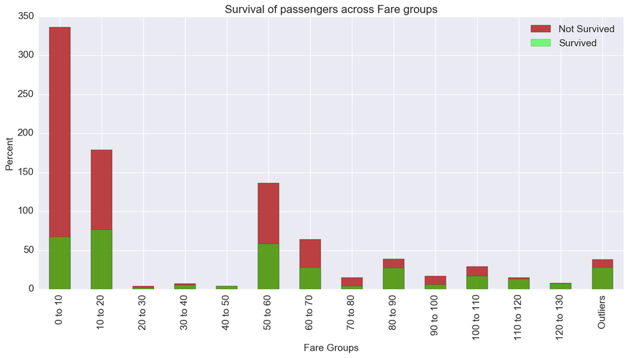

```python
figsize(15, 7)
total_people_by_fare_grp.plot(kind='bar', alpha=0.85, color='firebrick', fontsize=14)
survivals_by_fare_grp.plot(kind='bar', alpha=0.5, color='lime', fontsize=14)
plt.title('Survival of passengers across Fare groups', fontsize=16)
plt.legend(['Not Survived', 'Survived'], fontsize=14)
plt.ylabel('Percent', fontsize=14)
plt.xlabel('Fare Groups', fontsize=14)
plt.show()
```

- There is not much pattern from this plot. But one thing I can see that Fare groups below 30 died most, and fare groups greater than 30 has a better chance of surviving. The mean is 24, and 75% of fares lie below 28.50.
- Below Statistics.

  count ---> 853.00

  mean ---> 24.00

  std ---> 23.84

  min ---> 0.00

  25% ---> 7.90

  50% ---> 13.00

  75% ---> 28.50

  max ---> 120.00

### Check relationship between Age group & Fare Group

```python
people_by_age_fare_grp = titanic_df.groupby(by = ["Age_Group", "Fare_Group"]).size()
survived_by_age_fare_grp = titanic_df[titanic_df['Survived'] == 1].groupby(by = ["Age_Group", "Fare_Group"]).size()
people_by_age_fare_grp = people_by_age_fare_grp.unstack().fillna(-1).applymap(int).sort_index(ascending=False)
survived_by_age_fare_grp = survived_by_age_fare_grp.unstack().fillna(0).applymap(int).sort_index(ascending=False)
```

```python
people_by_age_fare_grp=people_by_age_fare_grp[['0 to 10', '10 to 20', '20 to 30', '30 to 40', \
                        '40 to 50', '50 to 60', '60 to 70', '70 to 80', '90 to 100',\
                        '100 to 110', '110 to 120', '120 to 130', 'Outliers'
                       ]]
people_by_age_fare_grp
```

| Fare_Group Age_Group | 0 to 10 | 10 to 20 | 20 to 30 | 30 to 40 | 40 to 50 | 50 to 60 | 60 to 70 | 70 to 80 | 90 to 100 | 100 to 110 | 110 to 120 | 120 to 130 | Outliers |
| --- | --- | --- | --- | --- | --- | --- | --- | --- | --- | --- | --- | --- | --- |
| Very Old | 2 | -1 | -1 | 2 | 1 | -1 | -1 | -1 | -1 | -1 | -1 | -1 | -1 |
| Old | 5 | 6 | 8 | 5 | -1 | -1 | 1 | 4 | -1 | -1 | 1 | -1 | 3 |
| Mid-Age | 27 | 21 | 24 | 8 | 1 | 11 | 3 | 8 | 2 | 1 | 1 | -1 | 6 |
| Adult | 159 | 78 | 60 | 20 | 3 | 23 | 4 | 9 | 4 | 1 | 2 | 2 | 16 |
| Youth | 132 | 46 | 19 | 10 | 5 | 5 | 8 | 8 | 2 | 2 | 2 | -1 | 10 |
| Child | 11 | 28 | 25 | 19 | 5 | -1 | 1 | -1 | -1 | -1 | 1 | 2 | 3 |

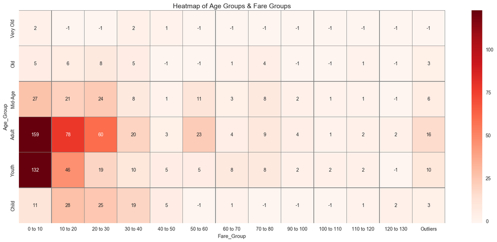

```python
p=figsize(20, 8)
g=sns.heatmap(people_by_age_fare_grp, annot=True,
              fmt="d", linewidths=0.2,
              linecolor="grey", cmap="Reds", robust=True, center=61
             )
plt.title("Heatmap of Age Groups & Fare Groups", fontsize = 14)
show(plt)
```

```python
survived_by_age_fare_grp=survived_by_age_fare_grp[['0 to 10', '10 to 20', '20 to 30', '30 to 40', \
                        '40 to 50', '50 to 60', '60 to 70', '70 to 80', '90 to 100',\
                        '100 to 110', '110 to 120', '120 to 130', 'Outliers'
                       ]]
survived_by_age_fare_grp
```

| Fare_Group Age_Group | 0 to 10 | 10 to 20 | 20 to 30 | 30 to 40 | 40 to 50 | 50 to 60 | 60 to 70 | 70 to 80 | 90 to 100 | 100 to 110 | 110 to 120 | 120 to 130 | Outliers |
| --- | --- | --- | --- | --- | --- | --- | --- | --- | --- | --- | --- | --- | --- |
| Very Old | 0 | 0 | 0 | 1 | 0 | 0 | 0 | 0 | 0 | 0 | 0 | 0 | 0 |
| Old | 1 | 1 | 1 | 1 | 0 | 0 | 0 | 3 | 0 | 0 | 0 | 0 | 2 |
| Mid-Age | 2 | 7 | 11 | 2 | 0 | 7 | 1 | 5 | 1 | 0 | 0 | 0 | 6 |
| Adult | 24 | 30 | 24 | 10 | 0 | 16 | 0 | 7 | 4 | 1 | 2 | 2 | 12 |
| Youth | 32 | 14 | 11 | 6 | 3 | 4 | 5 | 2 | 2 | 1 | 2 | 0 | 6 |
| Child | 8 | 24 | 11 | 8 | 1 | 0 | 0 | 0 | 0 | 0 | 1 | 2 | 2 |

```python
### Survivals by Age & Fare group
survival_pct_age_fare_grp = ((survived_by_age_fare_grp/people_by_age_fare_grp).fillna(0.001)*100).round(3)
survival_pct_age_fare_grp
```

| Fare_Group Age_Group | 0 to 10 | 10 to 20 | 20 to 30 | 30 to 40 | 40 to 50 | 50 to 60 | 60 to 70 | 70 to 80 | 90 to 100 | 100 to 110 | 110 to 120 | 120 to 130 | Outliers |
| --- | --- | --- | --- | --- | --- | --- | --- | --- | --- | --- | --- | --- | --- |
| Very Old | 0.000 | -0.000 | -0.000 | 50.000 | 0.0 | -0.000 | -0.000 | -0.000 | -0.0 | -0.0 | -0.0 | -0.0 | -0.000 |
| Old | 20.000 | 16.667 | 12.500 | 20.000 | -0.0 | -0.000 | 0.000 | 75.000 | -0.0 | -0.0 | 0.0 | -0.0 | 66.667 |
| Mid-Age | 7.407 | 33.333 | 45.833 | 25.000 | 0.0 | 63.636 | 33.333 | 62.500 | 50.0 | 0.0 | 0.0 | -0.0 | 100.000 |
| Adult | 15.094 | 38.462 | 40.000 | 50.000 | 0.0 | 69.565 | 0.000 | 77.778 | 100.0 | 100.0 | 100.0 | 100.0 | 75.000 |
| Youth | 24.242 | 30.435 | 57.895 | 60.000 | 60.0 | 80.000 | 62.500 | 25.000 | 100.0 | 50.0 | 100.0 | -0.0 | 60.000 |
| Child | 72.727 | 85.714 | 44.000 | 42.105 | 20.0 | -0.000 | 0.000 | -0.000 | -0.0 | -0.0 | 100.0 | 100.0 | 66.667 |

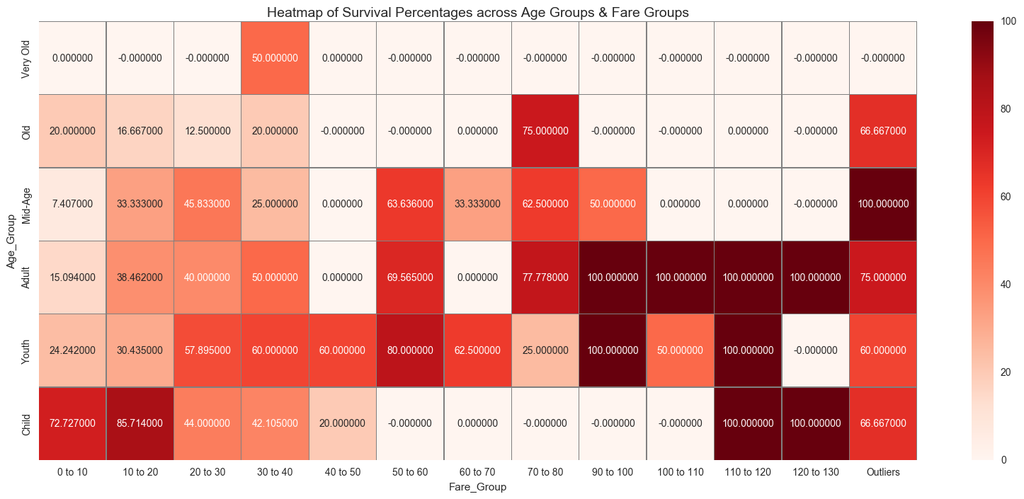

```python
p=figsize(20, 8)
g=sns.heatmap(survival_pct_age_fare_grp, annot=True,
              fmt="f", linewidths=0.2,
              linecolor="grey", cmap="Reds"
             )
plt.title("Heatmap of Survival Percentages across Age Groups & Fare Groups", fontsize=14)
show(plt)
```

### Create 2 fare groups -- less than 30 & 30+

```python
### It can be clearly seen that people having paid fare more than 50 had survived more
titanic_df['Another_Fare_Group'] = titanic_df['Fare'].apply(lambda fare : '30 or more' if fare >= 30 else '0 to 30')
titanic_df.head(3)
```

|  | PassengerId | Survived | Pclass | Sex | Age | SibSp | Parch | Ticket | Fare | Cabin | ... | Survival | Class | Family_Members_Count | Salutation | First_Name | Middle_Name | Last_Name | Age_Group | Fare_Group | Another_Fare_Group |
| --- | --- | --- | --- | --- | --- | --- | --- | --- | --- | --- | --- | --- | --- | --- | --- | --- | --- | --- | --- | --- | --- |
| 0 | 1 | 0 | 3 | M | 22.0 | 1 | 0 | A/5 21171 | 7.2500 | NaN | ... | Died | Third Class | 1 | Mr. | Owen | Harris | Braund | Youth | 0 to 10 | 0 to 30 |
| 1 | 2 | 1 | 1 | F | 38.0 | 1 | 0 | PC 17599 | 71.2833 | C85 | ... | Survived | First Class | 1 | Mrs. | John | Bradley | Cumings | Adult | 70 to 80 | 30 or more |
| 2 | 3 | 1 | 3 | F | 26.0 | 0 | 0 | STON/O2. 3101282 | 7.9250 | NaN | ... | Survived | Third Class | 0 | Miss. | Laina |  | Heikkinen | Adult | 0 to 10 | 0 to 30 |

3 rows × 21 columns

```python
people_per_new_fare_group = titanic_df.groupby(by = 'Another_Fare_Group').size()
people_per_new_fare_group
```

```
Another_Fare_Group
0 to 30       651
30 or more    240
dtype: int64
```

```python
survival_per_new_fare_group = titanic_df.query('Survived == 1').groupby(by = 'Another_Fare_Group').size()
survival_per_new_fare_group
```

```
Another_Fare_Group
0 to 30       201
30 or more    141
dtype: int64
```

```python
## Convert to Percents -- what is the percentage of people survived from each fare group
survival_per_new_fare_group.div(people_per_new_fare_group).round(4) * 100
```

```
Another_Fare_Group
0 to 30       30.88
30 or more    58.75
dtype: float64
```

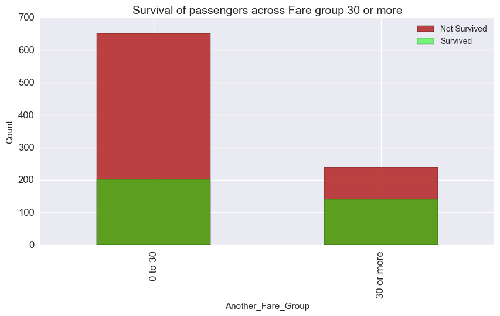

```python
figsize(10, 5)
people_per_new_fare_group.plot(kind='bar', alpha=0.85, color='firebrick',
                               fontsize = 12)
survival_per_new_fare_group.plot(kind='bar', alpha=0.5, color='lime', fontsize=12)
plt.title('Survival of passengers across Fare group 30 or more', fontsize = 14)
plt.legend(['Not Survived', 'Survived'])
plt.ylabel('Count')
plt.show()
```

### People who paid fare 30 or more have a very good survival rate as compared to people who paid less than 30.

## Analysis of Family-- Does families have a better chance of survival or other way

```python
family_group = titanic_df.groupby(by = 'Family_Members_Count').size()
family_group_survials = titanic_df.query('Survived == 1').groupby(by = 'Family_Members_Count').count()['Survived']

family_group, family_group_survials = family_group.align(other=family_group_survials, fill_value=0)
```

```python
family_group
```

```
Family_Members_Count
0     537
1     161
2     102
3      29
4      15
5      22
6      12
7       6
10      7
dtype: int64
```

```python
family_group_survials = family_group_survials.apply(int)
family_group_survials
```

```
Family_Members_Count
0     163
1      89
2      59
3      21
4       3
5       3
6       4
7       0
10      0
Name: Survived, dtype: int64
```

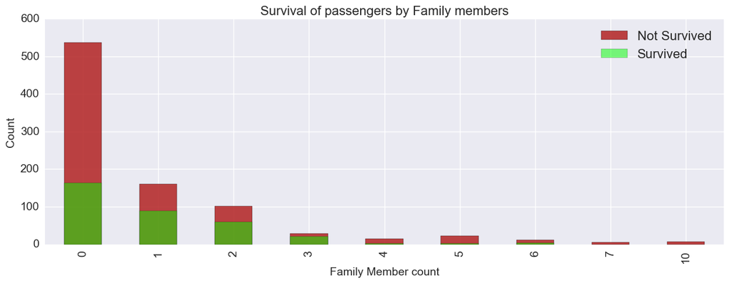

```python
figsize(15, 5)
family_group.plot(kind='bar', alpha=0.85, color='firebrick', fontsize=14)
family_group_survials.plot(kind='bar', alpha=0.5, color='lime', fontsize=14)
plt.title('Survival of passengers by Family members', fontsize=16)
plt.legend(['Not Survived', 'Survived'], fontsize=16)
plt.xlabel('Family Member count', fontsize=14)
plt.ylabel('Count', fontsize=14)
plt.show()
```

```python
### Add a new attribute that denotes if a person is traveling with family or not
titanic_df['Is_with_family'] = titanic_df['Family_Members_Count'].apply(\
                                    lambda family_members : 'No' if family_members == 0 else 'Yes')
titanic_df.head(3)
```

|  | PassengerId | Survived | Pclass | Sex | Age | SibSp | Parch | Ticket | Fare | Cabin | ... | Class | Family_Members_Count | Salutation | First_Name | Middle_Name | Last_Name | Age_Group | Fare_Group | Another_Fare_Group | Is_with_family |
| --- | --- | --- | --- | --- | --- | --- | --- | --- | --- | --- | --- | --- | --- | --- | --- | --- | --- | --- | --- | --- | --- |
| 0 | 1 | 0 | 3 | M | 22.0 | 1 | 0 | A/5 21171 | 7.2500 | NaN | ... | Third Class | 1 | Mr. | Owen | Harris | Braund | Youth | 0 to 10 | 0 to 30 | Yes |
| 1 | 2 | 1 | 1 | F | 38.0 | 1 | 0 | PC 17599 | 71.2833 | C85 | ... | First Class | 1 | Mrs. | John | Bradley | Cumings | Adult | 70 to 80 | 30 or more | Yes |
| 2 | 3 | 1 | 3 | F | 26.0 | 0 | 0 | STON/O2. 3101282 | 7.9250 | NaN | ... | Third Class | 0 | Miss. | Laina |  | Heikkinen | Adult | 0 to 10 | 0 to 30 | No |

3 rows × 22 columns

```python
# Family member count to Survivability
is_with_family_pivot = pd.pivot_table(data = titanic_df[['Survival', 'Is_with_family']],
                       index = 'Survival', columns = ['Is_with_family'], aggfunc = len).fillna(0)
is_with_family_pivot
```

| Is_with_family Survival | No | Yes |
| --- | --- | --- |
| Died | 374 | 175 |
| Survived | 163 | 179 |

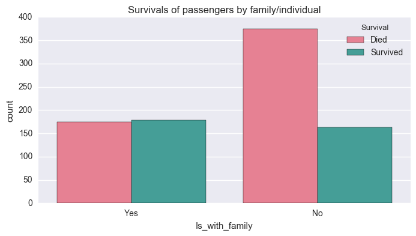

```python
figsize(8, 4)
# Plot distribution of Age Group Survivals
g=sns.countplot(x = 'Is_with_family',
              hue = 'Survival',
              data = titanic_df,
              palette = 'husl'
             )
sns.plt.title("Survivals of passengers by family/individual")
show(g)
```

### Clearly passengers traveling with family survived more than those who travelled alone.

### Hypothesis Testing -- passengers traveling with Family has better chance of Surviving as compared to people who travelled alone.

H0 : There is no significant relationship of survivals and traveling with family, i.e., we can say they are independent.

H1 : There is a relationship of survivals and traveling with family, i.e., we can say they are not independent.

```python
# Family member count to Survivability
pivot = pd.pivot_table(data = titanic_df[['Survival', 'Family_Members_Count']],
                       index = 'Survival', columns = ['Family_Members_Count'], aggfunc = len).fillna(0)
pivot
```

| Family_Members_Count Survival | 0 | 1 | 2 | 3 | 4 | 5 | 6 | 7 | 10 |
| --- | --- | --- | --- | --- | --- | --- | --- | --- | --- |
| Died | 374.0 | 72.0 | 43.0 | 8.0 | 12.0 | 19.0 | 8.0 | 6.0 | 7.0 |
| Survived | 163.0 | 89.0 | 59.0 | 21.0 | 3.0 | 3.0 | 4.0 | 0.0 | 0.0 |

```python
# Chi Square Testing
print "------ Results of Chi-Squared test on Sex to Survival. ------\n"
print "Does Sex have a significant effect on Survival?"

chi_square_test(pivot)
```

[output not shown]

```python
pivot = pd.pivot_table(data = titanic_df[['Survival', 'Is_with_family']],
                       index = 'Survival', columns = ['Is_with_family'], aggfunc = len).fillna(0)
pivot
```

| Is_with_family Survival | No | Yes |
| --- | --- | --- |
| Died | 374 | 175 |
| Survived | 163 | 179 |

```python
# Chi Square Testing
print "------ Results of Chi-Squared test on Sex to Survival. ------\n"
print "Does Sex have a significant effect on Survival?"

chi_square_test(pivot)
```

[output not shown]

### In both the cases the Chi-square scores are high and p-values are very less showing there is a very strong relationship between family member count and survivals, hence we will reject the null.

### Match the ticket -- Families should travel in same ticket

```python
def get_ticket_only_digit(ticket_data):
    for element in ticket_data:
        if str(element).isdigit():
            return element
```

```python
titanic_df['Ticket_Clean'] = titanic_df['Ticket'].str.split().apply(get_ticket_only_digit)
```

```python
titanic_df.head(3)
```

|  | PassengerId | Survived | Pclass | Sex | Age | SibSp | Parch | Ticket | Fare | Cabin | ... | Family_Members_Count | Salutation | First_Name | Middle_Name | Last_Name | Age_Group | Fare_Group | Another_Fare_Group | Is_with_family | Ticket_Clean |
| --- | --- | --- | --- | --- | --- | --- | --- | --- | --- | --- | --- | --- | --- | --- | --- | --- | --- | --- | --- | --- | --- |
| 0 | 1 | 0 | 3 | M | 22.0 | 1 | 0 | A/5 21171 | 7.2500 | NaN | ... | 1 | Mr. | Owen | Harris | Braund | Youth | 0 to 10 | 0 to 30 | Yes | 21171 |
| 1 | 2 | 1 | 1 | F | 38.0 | 1 | 0 | PC 17599 | 71.2833 | C85 | ... | 1 | Mrs. | John | Bradley | Cumings | Adult | 70 to 80 | 30 or more | Yes | 17599 |
| 2 | 3 | 1 | 3 | F | 26.0 | 0 | 0 | STON/O2. 3101282 | 7.9250 | NaN | ... | 0 | Miss. | Laina |  | Heikkinen | Adult | 0 to 10 | 0 to 30 | No | 3101282 |

3 rows × 23 columns

#### Families travel with same ticket

```python
family_groups = titanic_df.query('Family_Members_Count > 0').groupby(by='Ticket_Clean').size()
family_group_survivals = titanic_df.query('Family_Members_Count > 0 and Survived == 1').groupby(by='Ticket_Clean').size()
```

```python
print 'Total number of persons travelling with Family :: ', family_groups.sum()
print 'Total number of persons survived while travelling with Family :: ', family_group_survivals.sum()
print 'Family Survival Ratio :: ', round((float(family_group_survivals.sum()) * 100 / family_groups.sum()), 2)


print

#### Family Survival ratio is very good as compared to indidual people survivals
individual_survivals = titanic_df['Survived'].value_counts()[1] - family_group_survivals.sum()
print 'Total number of persons travelling without Family :: ', num_rows - family_groups.sum()
print 'Total number of persons survived travelling without Family :: ', individual_survivals
print 'Individual Survival Ratio :: ', round(float(individual_survivals) * 100 / (num_rows - family_groups.sum()), 2)
```

```
Total number of persons travelling with Family ::  354
Total number of persons survived while travelling with Family ::  179
Family Survival Ratio ::  50.56

Total number of persons travelling without Family ::  537
Total number of persons survived travelling without Family ::  163
Individual Survival Ratio ::  30.35
```

```python
### Survivals across families by SEX
females_in_family = titanic_df.query('Family_Members_Count > 0 and Sex == "F"').count()["PassengerId"]
female_survivals_in_family = titanic_df.query('Family_Members_Count > 0 and Survived == 1 and Sex == "F"').groupby(by='Ticket_Clean').size().sum()
print 'Female survivals in Family :: ', female_survivals_in_family
print 'Total females in families :: ', females_in_family
print 'Family females survival ratio :: ', round(float(female_survivals_in_family * 100) / females_in_family, 2)
```

```
Female survivals in Family ::  134
Total females in families ::  188
Family females survival ratio ::  71.28
```

```python
male_survivals_in_family = family_group_survivals.sum() - female_survivals_in_family
males_in_family = titanic_df.query('Family_Members_Count > 0 and Sex == "M"').groupby(by='Ticket_Clean').size().sum()
print 'Male survivals in Family :: ', male_survivals_in_family
print 'Total males in families :: ', males_in_family
print 'Family males survival ratio :: ', round(float(male_survivals_in_family * 100) / males_in_family, 2)
```

```
Male survivals in Family ::  45
Total males in families ::  166
Family males survival ratio ::  27.11
```

## Conclusion

There are a number of that conclusions can be drawn from the analysis. But I will limit it to the question I thought most interesting and presented at the beginning. This report entirely try to analyse the dataset and present meaningful answers/findings that can be seen from it. Again the findings are presented with visuals and written analysis.

This report does not build any model that can use this dataset as test dataset and make predictions out of other similar datasets. In future the dataset can be used to built models that can learn from this data and predict survivals from similar datasets.